# Weight Lift Exercise Prediction Assignment

Sinto Ling

Sunday, January 31, 2016

## Introduction

This write up is for the Practical Machine Learning class from the Coursera Data Science Specialization. It is offered through Coursera by Johns Hopkins University Bloomberg School of Public Health. In this write up, weight lifting exercise data is analysed and a prediction model is generated. All the data is made available by the collaborators listed on this website: http://groupware.les.inf.puc-rio.br/har

## Data Load & Clean Up

Let’s start by loading the files and taking a look at the data.

```r
pml_train <- read.csv("pml-training.csv", na.strings = c("NA", "#DIV/0!", ""))
pml_test <- read.csv("pml-testing.csv", na.strings = c("NA", "#DIV/0!", ""))
str(pml_train, list.len=20)
```

```
## 'data.frame':    19622 obs. of  160 variables:
##  $ X                       : int  1 2 3 4 5 6 7 8 9 10 ...
##  $ user_name               : Factor w/ 6 levels "adelmo","carlitos",..: 2 2 2 2 2 2 2 2 2 2 ...
##  $ raw_timestamp_part_1    : int  1323084231 1323084231 1323084231 1323084232 1323084232 1323084232 1323084232 1323084232 1323084232 1323084232 ...
##  $ raw_timestamp_part_2    : int  788290 808298 820366 120339 196328 304277 368296 440390 484323 484434 ...
##  $ cvtd_timestamp          : Factor w/ 20 levels "02/12/2011 13:32",..: 9 9 9 9 9 9 9 9 9 9 ...
##  $ new_window              : Factor w/ 2 levels "no","yes": 1 1 1 1 1 1 1 1 1 1 ...
##  $ num_window              : int  11 11 11 12 12 12 12 12 12 12 ...
##  $ roll_belt               : num  1.41 1.41 1.42 1.48 1.48 1.45 1.42 1.42 1.43 1.45 ...
##  $ pitch_belt              : num  8.07 8.07 8.07 8.05 8.07 8.06 8.09 8.13 8.16 8.17 ...
##  $ yaw_belt                : num  -94.4 -94.4 -94.4 -94.4 -94.4 -94.4 -94.4 -94.4 -94.4 -94.4 ...
##  $ total_accel_belt        : int  3 3 3 3 3 3 3 3 3 3 ...
##  $ kurtosis_roll_belt      : num  NA NA NA NA NA NA NA NA NA NA ...
##  $ kurtosis_picth_belt     : num  NA NA NA NA NA NA NA NA NA NA ...
##  $ kurtosis_yaw_belt       : logi  NA NA NA NA NA NA ...
##  $ skewness_roll_belt      : num  NA NA NA NA NA NA NA NA NA NA ...
##  $ skewness_roll_belt.1    : num  NA NA NA NA NA NA NA NA NA NA ...
##  $ skewness_yaw_belt       : logi  NA NA NA NA NA NA ...
##  $ max_roll_belt           : num  NA NA NA NA NA NA NA NA NA NA ...
##  $ max_picth_belt          : int  NA NA NA NA NA NA NA NA NA NA ...
##  $ max_yaw_belt            : num  NA NA NA NA NA NA NA NA NA NA ...
##   [list output truncated]
```

The first 6 columns are not important for prediction since they are just the user information. There are also many NAs in other columns, which will be handled appropriately later.

```r
pml_train <- pml_train[,7:160] # first 6 are just user info.
pml_test <- pml_test[,7:160]
```

## Data Manipulation

Now divide up the training set into a training set (t1) and a test set (t2). We want to remove zero covariates while we’re doing this because they are of low importance. We also want to get rid of any columns that have too many NAs, as they will not be useful to the prediction model.

```r
library(caret)
set.seed(345200)
inTrain <- createDataPartition(y=pml_train$classe, p=0.6, list=FALSE)
t1 <- pml_train[inTrain,] # use this as main training set
t2 <- pml_train[-inTrain,] # use for cross validation
dim(t1); dim(t2) # verify dimensions
```

```
## [1] 11776   154
```

```
## [1] 7846  154
```

```r
## Remove zero covariates
nzcol <- nearZeroVar(t1)
if (length(nzcol) > 0) {
    t1 <- t1[, -nzcol]
    t2 <- t2[, -nzcol]
}

## Keep columns that don't have many NAs
keepCols <- apply(!is.na(t1), 2, sum)/nrow(t1) > 0.9
t1 <- t1[, keepCols]
t2 <- t2[, keepCols]
```

## Predicting With Tree

Next I use the rpart function as part of the rpart library to find the regression tree with “classe” as the response variable.

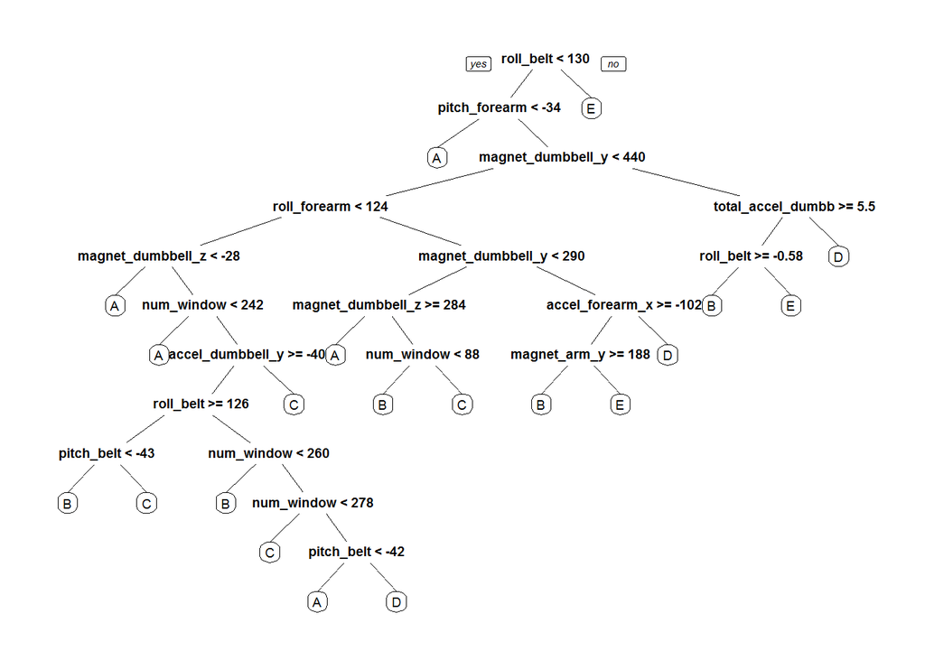

```r
library(rpart); library(rpart.plot)
fitModel <- rpart(classe~., data=t1, method="class")
prp(fitModel, cex=0.6)
```

```r
fitCol <- c("roll_belt", "pitch_forearm", "magnet_dumbbell_y", "roll_forearm", "pitch_belt", "total_accel_dumbbell", "num_window", "magnet_dumbbell_z", "magnet_arm_y")
corMatrix <- abs(cor(t1[,fitCol]))
diag(corMatrix) <- 0 # set diagonal to 0
any(corMatrix > 0.8)
```

```
## [1] FALSE
```

```r
print(max(corMatrix)) # max correlation is only 0.4987
```

```
## [1] 0.4987177
```

## Build Prediction Model

Now that we have our predictor variables, we can build the prediction model.

```r
library(randomForest)
fitModel <- train(classe~roll_belt+pitch_forearm+magnet_dumbbell_y+roll_forearm+pitch_belt+
                      total_accel_dumbbell+num_window+magnet_dumbbell_z+magnet_arm_y,
                  data=t1, method="rf", trControl=trainControl(method="cv", number=2))
# for cross validation, with the large dataset, we could set 2-fold
```

Now let’s try our model with the test set (t2).

```r
predictions <- predict(fitModel, newdata=t2)
CM <- confusionMatrix(predictions, t2$classe)
print(CM$overall[1])
```

```
##  Accuracy
## 0.9978333
```

```r
OOSE <- unname(1 - CM$overall[1]) # Out-Of-Sample Error Rate
print(OOSE)
```

```
## [1] 0.002166709
```